# Study 1 — Subjective Ratings: Mixed Models

2025-04-25

Siyuan Huang

# Overview

This document models overall response quality (the mean of the four rating dimensions) for Top vs. Bottom models, as judged by the two rater groups (students, instructors). The primary model (`model1`) clusters repeated ratings on the explanation output (`Model × Task × Iteration`) via `(1 | Explanation)` — the unit the eight raters score in common — together with `(1 | Rater)`. This primary model is reported in full with Type-III ANOVA, effect sizes, post-hoc contrasts, and diagnostics. A supplementary section then refits the model with random effects of `(1 | Attempt)` together with `(1 | Rater)`.

## Packages

```r
library(readxl)
library(dplyr)
library(stringr)
library(lme4)
library(lmerTest)
library(car)
library(effectsize)
library(emmeans)
library(performance)
library(report)
library(ggplot2)
```

## Load Data

```r
df <- read_excel("data/Study_1_Subjective_Data.xlsx")
head(df)
```

```
## # A tibble: 6 × 10
##   Task  Number Statistical_Accuracy Clarity_and_Structure Conceptual_Depth
##   <chr>  <dbl>                <dbl>                 <dbl>            <dbl>
## 1 Q1         1                    6                     7                5
## 2 Q1         2                    6                     5                6
## 3 Q1         3                    3                     5                5
## 4 Q1         4                    4                     7                5
## 5 Q1         5                    5                     7                5
## 6 Q1         6                    6                     7                5
## # ℹ 5 more variables: Pedagogical_Effectiveness <dbl>, Iteration <dbl>,
## #   Model <chr>, ID <dbl>, Profession <chr>
```

## Recode Core Variables

Design variables are coerced to factors; a unique `Rater` identifier and the composite `OverallQuality` outcome are constructed, and models are grouped into Top/Bottom/Other from the objective benchmark ranking.

```r
df <- df %>%
  mutate(
    Model = factor(Model),
    Profession = factor(Profession),
    Task = factor(Task),
    Iteration = factor(Iteration),
    ID = factor(ID),
    RaterGroup = Profession,
    Attempt = Iteration,
    Rater = factor(paste(RaterGroup, ID, sep = "_")),
    # Explanation = the unique output that all raters score in common
    # (Model × Task × Iteration), used as the repeated-measures
    # clustering unit in the primary model.
    Explanation = factor(paste(Model, Task, Iteration, sep = "_")),
    OverallQuality = rowMeans(
      across(
        c(
          Statistical_Accuracy,
          Clarity_and_Structure,
          Conceptual_Depth,
          Pedagogical_Effectiveness
        )
      ),
      na.rm = TRUE
    ),
    ModelGroup = case_when(
      str_detect(Model, regex("ChatGPT_4o", ignore_case = TRUE)) ~ "Top",
      str_detect(Model, regex("ChatGPT_o1", ignore_case = TRUE)) ~ "Top",
      str_detect(Model, regex("Grok3", ignore_case = TRUE)) ~ "Bottom",
      str_detect(Model, regex("Gemini_2\\.0", ignore_case = TRUE)) ~ "Bottom",
      TRUE ~ "Other"
    ),
    ModelGroup = factor(ModelGroup, levels = c("Bottom", "Top", "Other"))
  )

# Sanity check: number of unique explanation outputs, and how many raters
# score each one (should be a constant panel size of 8).
length(levels(df$Explanation))
```

```
## [1] 36
```

```r
table(table(df$Explanation))
```

```
##
##  8
## 36
```

## Filter Top and Bottom Models

```r
df_tb <- df %>%
  filter(ModelGroup %in% c("Top", "Bottom")) %>%
  droplevels()
```

## Model Fitting

### Raw Data Plot

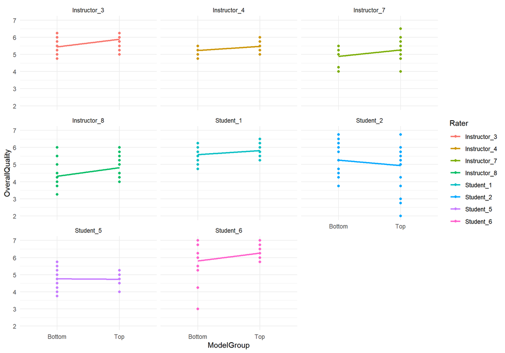

```r
ggplot(df, aes(x = ModelGroup, y = OverallQuality)) +
  geom_point(aes(color = Rater)) +
  geom_smooth(method = "lm", se = FALSE, aes(group = Rater, color = Rater)) +
  facet_wrap(~Rater) +
  theme_minimal()
```

### Model 1 — Primary: `(1 | Rater) + (1 | Explanation)`

```r
# Model 1 (primary): repeated ratings are clustered on the
# explanation output (Model × Task × Iteration) via (1 | Explanation),
# the unit the 8 raters score in common.
model1 <- lmer(
  OverallQuality ~ ModelGroup * RaterGroup * Task +
    (1 | Rater) + (1 | Explanation),
  data = df
)

summary(model1)
```

```
## Linear mixed model fit by REML. t-tests use Satterthwaite's method [
## lmerModLmerTest]
## Formula: OverallQuality ~ ModelGroup * RaterGroup * Task + (1 | Rater) +
##     (1 | Explanation)
##    Data: df
##
## REML criterion at convergence: 596.9
##
## Scaled residuals:
##     Min      1Q  Median      3Q     Max
## -4.4565 -0.4612  0.0617  0.5325  2.8899
##
## Random effects:
##  Groups      Name        Variance Std.Dev.
##  Explanation (Intercept) 0.01127  0.1062
##  Rater       (Intercept) 0.26437  0.5142
##  Residual                0.40467  0.6361
## Number of obs: 288, groups:  Explanation, 36; Rater, 8
##
## Fixed effects:
##                                         Estimate Std. Error        df t value
## (Intercept)                              4.97917    0.29126   9.05285  17.095
## ModelGroupTop                            0.48958    0.19360  91.48216   2.529
## RaterGroupStudent                        0.25000    0.40732   8.68753   0.614
## TaskQ2                                  -0.05208    0.19360  91.48216  -0.269
## TaskQ3                                   0.03125    0.19360  91.48216   0.161
## ModelGroupTop:RaterGroupStudent          0.01042    0.25970 239.99998   0.040
## ModelGroupTop:TaskQ2                     0.03125    0.27379  91.48216   0.114
## ModelGroupTop:TaskQ3                    -0.33333    0.27379  91.48216  -1.217
## RaterGroupStudent:TaskQ2                 0.09375    0.25970 239.99998   0.361
## RaterGroupStudent:TaskQ3                 0.30208    0.25970 239.99998   1.163
## ModelGroupTop:RaterGroupStudent:TaskQ2  -0.63542    0.36727 239.99998  -1.730
## ModelGroupTop:RaterGroupStudent:TaskQ3  -0.30208    0.36727 239.99998  -0.823
##                                        Pr(>|t|)
## (Intercept)                            3.36e-08 ***
## ModelGroupTop                            0.0132 *
## RaterGroupStudent                        0.5551
## TaskQ2                                   0.7885
## TaskQ3                                   0.8721
## ModelGroupTop:RaterGroupStudent          0.9680
```

[output cut: 19 more lines]

```
## RtrGrpS:TQ3  0.223 -0.335 -0.319 -0.335 -0.671  0.500    0.237   0.474   0.500
## MGT:RGS:TQ2 -0.158  0.474  0.225  0.474  0.237 -0.707   -0.671  -0.335  -0.707
## MGT:RGS:TQ3 -0.158  0.474  0.225  0.237  0.474 -0.707   -0.335  -0.671  -0.354
##             RGS:TQ3 MGT:RGS:TQ2
## ModelGropTp
## RtrGrpStdnt
## TaskQ2
## TaskQ3
## MdlGrpT:RGS
## MdlGrpT:TQ2
## MdlGrpT:TQ3
## RtrGrpS:TQ2
## RtrGrpS:TQ3
## MGT:RGS:TQ2 -0.354
## MGT:RGS:TQ3 -0.707   0.500
```

### Standardised Parameters

```r
standardize_parameters(model1)
```

```
## # Standardization method: refit
##
## Parameter                                             | Std. Coef. |        95% CI
## ----------------------------------------------------------------------------------
## (Intercept)                                           |      -0.37 | [-1.08, 0.33]
## ModelGroup [Top]                                      |       0.61 | [ 0.13, 1.08]
## RaterGroup [Student]                                  |       0.31 | [-0.68, 1.30]
## Task [Q2]                                             |      -0.06 | [-0.54, 0.41]
## Task [Q3]                                             |       0.04 | [-0.43, 0.51]
## ModelGroup [Top] × RaterGroup [Student]               |       0.01 | [-0.62, 0.64]
## ModelGroup [Top] × Task [Q2]                          |       0.04 | [-0.63, 0.70]
## ModelGroup [Top] × Task [Q3]                          |      -0.41 | [-1.08, 0.25]
## RaterGroup [Student] × Task [Q2]                      |       0.12 | [-0.52, 0.75]
## RaterGroup [Student] × Task [Q3]                      |       0.37 | [-0.26, 1.01]
## (ModelGroup [Top] × RaterGroup [Student]) × Task [Q2] |      -0.79 | [-1.68, 0.11]
## (ModelGroup [Top] × RaterGroup [Student]) × Task [Q3] |      -0.37 | [-1.27, 0.52]
```

### Type-III ANOVA and Effect Sizes

```r
aov_model1 <- anova(model1)
aov_model1
```

```
## Type III Analysis of Variance Table with Satterthwaite's method
##                            Sum Sq Mean Sq NumDF DenDF F value   Pr(>F)
## ModelGroup                 3.3309  3.3309     1    30  8.2313 0.007472 **
## RaterGroup                 0.1566  0.1566     1     6  0.3869 0.556820
## Task                       0.8756  0.4378     2    30  1.0819 0.351803
## ModelGroup:RaterGroup      1.6426  1.6426     1   240  4.0591 0.045049 *
## ModelGroup:Task            2.3280  1.1640     2    30  2.8765 0.071967 .
## RaterGroup:Task            1.7088  0.8544     2   240  2.1113 0.123320
## ModelGroup:RaterGroup:Task 1.2122  0.6061     2   240  1.4978 0.225698
## ---
## Signif. codes:  0 '***' 0.001 '**' 0.01 '*' 0.05 '.' 0.1 ' ' 1
```

```r
eta_squared(model1)
```

```
## # Effect Size for ANOVA (Type III)
##
## Parameter                  | Eta2 (partial) |       95% CI
## ----------------------------------------------------------
## ModelGroup                 |           0.22 | [0.04, 1.00]
## RaterGroup                 |           0.06 | [0.00, 1.00]
## Task                       |           0.07 | [0.00, 1.00]
## ModelGroup:RaterGroup      |           0.02 | [0.00, 1.00]
## ModelGroup:Task            |           0.16 | [0.00, 1.00]
## RaterGroup:Task            |           0.02 | [0.00, 1.00]
## ModelGroup:RaterGroup:Task |           0.01 | [0.00, 1.00]
##
## - One-sided CIs: upper bound fixed at [1.00].
```

### Post-hoc

```r
emmeans(model1, pairwise ~ ModelGroup, infer = c(TRUE, TRUE))
```

```
## $emmeans
##  ModelGroup emmean    SE   df lower.CL upper.CL t.ratio p.value
##  Bottom       5.16 0.191 6.71     4.71     5.62  27.032  <.0001
##  Top          5.40 0.191 6.71     4.95     5.86  28.277  <.0001
##
## Results are averaged over the levels of: RaterGroup, Task
## Degrees-of-freedom method: kenward-roger
## Confidence level used: 0.95
##
## $contrasts
##  contrast     estimate     SE df lower.CL upper.CL t.ratio p.value
##  Bottom - Top   -0.238 0.0829 30   -0.407  -0.0685  -2.869  0.0075
##
## Results are averaged over the levels of: RaterGroup, Task
## Degrees-of-freedom method: kenward-roger
## Confidence level used: 0.95
```

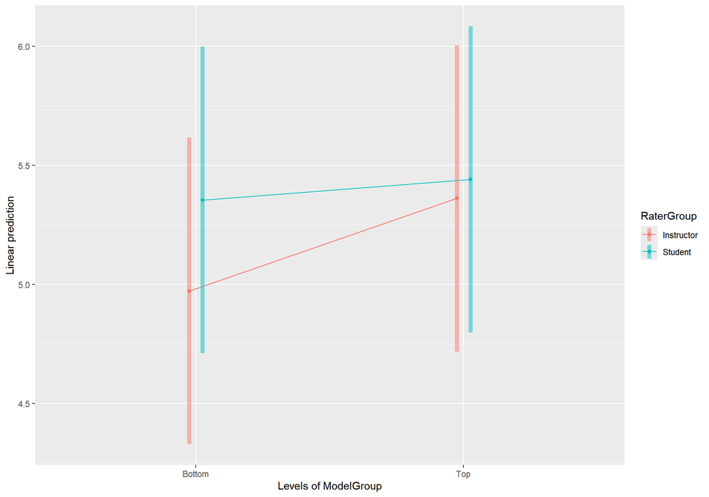

```r
emmip(model1, RaterGroup ~ ModelGroup, CIs = TRUE)
```

```r
emmeans(model1, pairwise ~ ModelGroup * RaterGroup, infer = c(TRUE, TRUE))
```

```
## $emmeans
##  ModelGroup RaterGroup emmean    SE   df lower.CL upper.CL t.ratio p.value
##  Bottom     Instructor   4.97 0.269 6.61     4.33     5.62  18.487  <.0001
##  Top        Instructor   5.36 0.269 6.61     4.72     6.00  19.933  <.0001
##  Bottom     Student      5.35 0.269 6.61     4.71     6.00  19.907  <.0001
##  Top        Student      5.44 0.269 6.61     4.80     6.08  20.230  <.0001
##
## Results are averaged over the levels of: Task
## Degrees-of-freedom method: kenward-roger
## Confidence level used: 0.95
##
## $contrasts
##  contrast                           estimate    SE    df lower.CL upper.CL
##  Bottom Instructor - Top Instructor -0.38889 0.112 91.48   -0.681  -0.0964
##  Bottom Instructor - Bottom Student -0.38194 0.379  6.50   -1.662   0.8978
##  Bottom Instructor - Top Student    -0.46875 0.380  6.61   -1.748   0.8103
##  Top Instructor - Bottom Student     0.00694 0.380  6.61   -1.272   1.2860
##  Top Instructor - Top Student       -0.07986 0.379  6.50   -1.360   1.1999
##  Bottom Student - Top Student       -0.08681 0.112 91.48   -0.379   0.2057
##  t.ratio p.value
##   -3.479  0.0042
##   -1.009  0.7505
##   -1.232  0.6291
##    0.018  1.0000
##   -0.211  0.9963
##   -0.777  0.8648
##
## Results are averaged over the levels of: Task
## Degrees-of-freedom method: kenward-roger
## Confidence level used: 0.95
## Conf-level adjustment: tukey method for comparing a family of 4 estimates
## P value adjustment: tukey method for comparing a family of 4 estimates
```

```r
report(aov_model1)
```

```
## The ANOVA suggests that:
##
##   - The main effect of ModelGroup is statistically significant and large (F(1) =
## 8.23, p = 0.007; Eta2 (partial) = 0.22, 95% CI [0.04, 1.00])
##   - The main effect of RaterGroup is statistically not significant and medium
## (F(1) = 0.39, p = 0.557; Eta2 (partial) = 0.06, 95% CI [0.00, 1.00])
##   - The main effect of Task is statistically not significant and medium (F(2) =
## 1.08, p = 0.352; Eta2 (partial) = 0.07, 95% CI [0.00, 1.00])
##   - The interaction between ModelGroup and RaterGroup is statistically
## significant and small (F(1) = 4.06, p = 0.045; Eta2 (partial) = 0.02, 95% CI
## [1.93e-04, 1.00])
##   - The interaction between ModelGroup and Task is statistically not significant
## and large (F(2) = 2.88, p = 0.072; Eta2 (partial) = 0.16, 95% CI [0.00, 1.00])
##   - The interaction between RaterGroup and Task is statistically not significant
## and small (F(2) = 2.11, p = 0.123; Eta2 (partial) = 0.02, 95% CI [0.00, 1.00])
##   - The interaction between ModelGroup, RaterGroup and Task is statistically not
## significant and small (F(2) = 1.50, p = 0.226; Eta2 (partial) = 0.01, 95% CI
## [0.00, 1.00])
##
## Effect sizes were labelled following Field's (2013) recommendations.
```

### Diagnostics

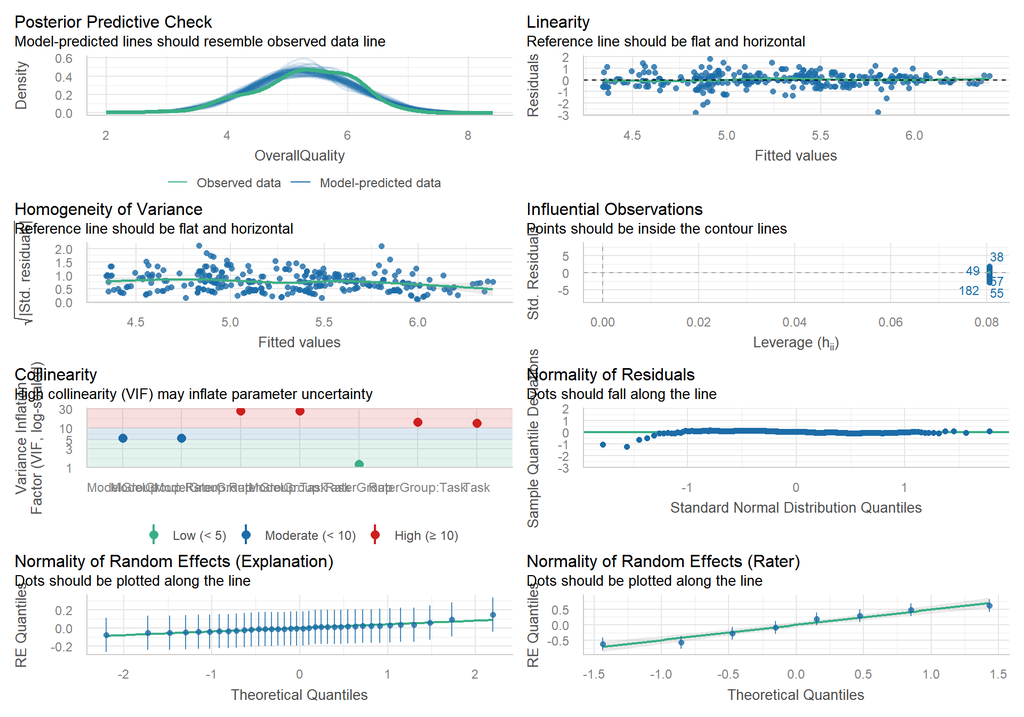

```r
performance::check_model(model1)
```

```r
performance::check_collinearity(model1)
```

```
## # Check for Multicollinearity
##
## Low Correlation
##
##        Term  VIF     VIF 95% CI adj. VIF Tolerance Tolerance 95% CI
##  RaterGroup 1.20 [ 1.10,  1.43]     1.10      0.83     [0.70, 0.91]
##
## Moderate Correlation
##
##                   Term  VIF     VIF 95% CI adj. VIF Tolerance Tolerance 95% CI
##             ModelGroup 5.45 [ 4.49,  6.68]     2.34      0.18     [0.15, 0.22]
##  ModelGroup:RaterGroup 5.58 [ 4.59,  6.84]     2.36      0.18     [0.15, 0.22]
##
## High Correlation
##
##                        Term   VIF     VIF 95% CI adj. VIF Tolerance
##                        Task 13.22 [10.72, 16.35]     3.64      0.08
##             ModelGroup:Task 26.43 [21.34, 32.81]     5.14      0.04
##             RaterGroup:Task 13.81 [11.20, 17.09]     3.72      0.07
##  ModelGroup:RaterGroup:Task 26.73 [21.57, 33.18]     5.17      0.04
##  Tolerance 95% CI
##      [0.06, 0.09]
##      [0.03, 0.05]
##      [0.06, 0.09]
##      [0.03, 0.05]
```

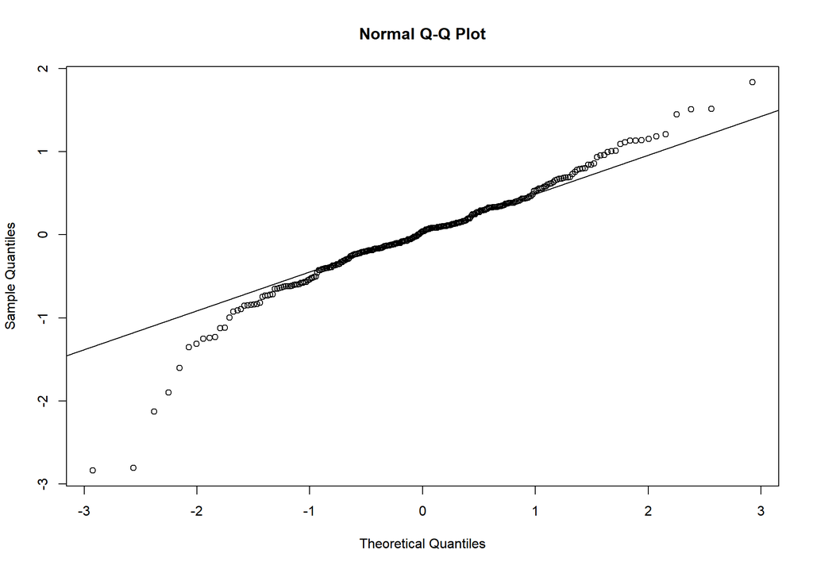

```r
res <- residuals(model1)
qqnorm(res)
qqline(res)
```

# Supplementary Analysis — Original Iteration-Only Clustering

## Refit with `(1 | Attempt)`

```r
model1_attempt <- lmer(
  OverallQuality ~ ModelGroup * RaterGroup * Task +
    (1 | Rater) + (1 | Attempt),
  data = df
)

summary(model1_attempt)
```

```
## Linear mixed model fit by REML. t-tests use Satterthwaite's method [
## lmerModLmerTest]
## Formula: OverallQuality ~ ModelGroup * RaterGroup * Task + (1 | Rater) +
##     (1 | Attempt)
##    Data: df
##
## REML criterion at convergence: 597.5
##
## Scaled residuals:
##     Min      1Q  Median      3Q     Max
## -4.4809 -0.5164  0.0648  0.5490  2.7983
##
## Random effects:
##  Groups   Name        Variance Std.Dev.
##  Rater    (Intercept) 0.2641   0.5139
##  Attempt  (Intercept) 0.0000   0.0000
##  Residual             0.4147   0.6440
## Number of obs: 288, groups:  Rater, 8; Attempt, 3
##
## Fixed effects:
##                                         Estimate Std. Error        df t value
## (Intercept)                              4.97917    0.28862   8.76115  17.252
## ModelGroupTop                            0.48958    0.18590 270.00000   2.634
## RaterGroupStudent                        0.25000    0.40817   8.76115   0.612
## TaskQ2                                  -0.05208    0.18590 270.00000  -0.280
## TaskQ3                                   0.03125    0.18590 270.00000   0.168
## ModelGroupTop:RaterGroupStudent          0.01042    0.26290 270.00000   0.040
## ModelGroupTop:TaskQ2                     0.03125    0.26290 270.00000   0.119
## ModelGroupTop:TaskQ3                    -0.33333    0.26290 270.00000  -1.268
## RaterGroupStudent:TaskQ2                 0.09375    0.26290 270.00000   0.357
## RaterGroupStudent:TaskQ3                 0.30208    0.26290 270.00000   1.149
## ModelGroupTop:RaterGroupStudent:TaskQ2  -0.63542    0.37179 270.00000  -1.709
## ModelGroupTop:RaterGroupStudent:TaskQ3  -0.30208    0.37179 270.00000  -0.813
##                                        Pr(>|t|)
## (Intercept)                            4.58e-08 ***
## ModelGroupTop                           0.00893 **
## RaterGroupStudent                       0.55578
## TaskQ2                                  0.77956
## TaskQ3                                  0.86663
## ModelGroupTop:RaterGroupStudent         0.96842
```

[output cut: 21 more lines]

```
## MGT:RGS:TQ3 -0.161  0.500  0.228  0.250  0.500 -0.707   -0.354  -0.707  -0.354
##             RGS:TQ3 MGT:RGS:TQ2
## ModelGropTp
## RtrGrpStdnt
## TaskQ2
## TaskQ3
## MdlGrpT:RGS
## MdlGrpT:TQ2
## MdlGrpT:TQ3
## RtrGrpS:TQ2
## RtrGrpS:TQ3
## MGT:RGS:TQ2 -0.354
## MGT:RGS:TQ3 -0.707   0.500
## optimizer (nloptwrap) convergence code: 0 (OK)
## boundary (singular) fit: see help('isSingular')
```

## Comparing the two clustering structures

```r
compare_performance(model1, model1_attempt, rank = TRUE)
```

```
## Random effect variances not available. Returned R2 does not account for random effects.
```

```
## # Comparison of Model Performance Indices
##
## Name           |           Model | R2 (marg.) |  RMSE | Sigma | AIC weights
## ---------------------------------------------------------------------------
## model1_attempt | lmerModLmerTest |      0.121 | 0.624 | 0.644 |       0.525
## model1         | lmerModLmerTest |      0.077 | 0.610 | 0.636 |       0.475
##
## Name           | AICc weights | BIC weights | Performance-Score
## ---------------------------------------------------------------
## model1_attempt |        0.525 |       0.525 |            66.67%
## model1         |        0.475 |       0.475 |            33.33%
```

```r
VarCorr(model1)          # primary: explanation-level SD is non-zero
```

```
##  Groups      Name        Std.Dev.
##  Explanation (Intercept) 0.10617
##  Rater       (Intercept) 0.51417
##  Residual                0.63613
```

```r
VarCorr(model1_attempt)  # iteration-only: Attempt variance is estimated at 0
```

```
##  Groups   Name        Std.Dev.
##  Rater    (Intercept) 0.51390
##  Attempt  (Intercept) 0.00000
##  Residual             0.64396
```

## Inferential consequence

```r
aov_model1_attempt <- anova(model1_attempt)
aov_model1_attempt
```

```
## Type III Analysis of Variance Table with Satterthwaite's method
##                            Sum Sq Mean Sq NumDF DenDF F value   Pr(>F)
## ModelGroup                 4.0731  4.0731     1   270  9.8222 0.001914 **
## RaterGroup                 0.1604  0.1604     1     6  0.3869 0.556820
## Task                       1.0707  0.5354     2   270  1.2910 0.276677
## ModelGroup:RaterGroup      1.6426  1.6426     1   270  3.9610 0.047574 *
## ModelGroup:Task            2.8468  1.4234     2   270  3.4325 0.033723 *
## RaterGroup:Task            1.7088  0.8544     2   270  2.0603 0.129412
## ModelGroup:RaterGroup:Task 1.2122  0.6061     2   270  1.4616 0.233684
## ---
## Signif. codes:  0 '***' 0.001 '**' 0.01 '*' 0.05 '.' 0.1 ' ' 1
```

### Post-hoc

```r
emmeans(model1_attempt, pairwise ~ ModelGroup, infer = c(TRUE, TRUE))
```

```
## $emmeans
##  ModelGroup emmean    SE   df lower.CL upper.CL t.ratio p.value
##  Bottom       5.16 0.189 6.48     4.71     5.62  27.253  <.0001
##  Top          5.40 0.189 6.48     4.95     5.86  28.509  <.0001
##
## Results are averaged over the levels of: RaterGroup, Task
## Degrees-of-freedom method: kenward-roger
## Confidence level used: 0.95
##
## $contrasts
##  contrast     estimate     SE  df lower.CL upper.CL t.ratio p.value
##  Bottom - Top   -0.238 0.0759 268   -0.387  -0.0884  -3.134  0.0019
##
## Results are averaged over the levels of: RaterGroup, Task
## Degrees-of-freedom method: kenward-roger
## Confidence level used: 0.95
```

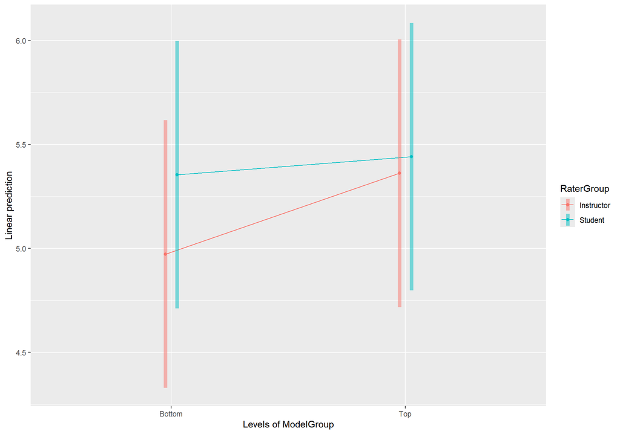

```r
emmip(model1_attempt, RaterGroup ~ ModelGroup, CIs = TRUE)
```

```r
emmeans(model1_attempt, pairwise ~ ModelGroup * RaterGroup, infer = c(TRUE, TRUE))
```

```
## $emmeans
##  ModelGroup RaterGroup emmean    SE  df lower.CL upper.CL t.ratio p.value
##  Bottom     Instructor   4.97 0.268 6.5     4.33     5.62  18.558  <.0001
##  Top        Instructor   5.36 0.268 6.5     4.72     6.00  20.010  <.0001
##  Bottom     Student      5.35 0.268 6.5     4.71     6.00  19.984  <.0001
##  Top        Student      5.44 0.268 6.5     4.80     6.08  20.308  <.0001
##
## Results are averaged over the levels of: Task
## Degrees-of-freedom method: kenward-roger
## Confidence level used: 0.95
##
## $contrasts
##  contrast                           estimate    SE     df lower.CL upper.CL
##  Bottom Instructor - Top Instructor -0.38889 0.107 268.00   -0.666   -0.111
##  Bottom Instructor - Bottom Student -0.38194 0.379   6.51   -1.662    0.898
##  Bottom Instructor - Top Student    -0.46875 0.379   6.51   -1.748    0.811
##  Top Instructor - Bottom Student     0.00694 0.379   6.51   -1.273    1.287
##  Top Instructor - Top Student       -0.07986 0.379   6.51   -1.359    1.200
##  Bottom Student - Top Student       -0.08681 0.107 268.00   -0.364    0.191
##  t.ratio p.value
##   -3.623  0.0020
##   -1.008  0.7507
##   -1.237  0.6269
##    0.018  1.0000
##   -0.211  0.9964
##   -0.809  0.8503
##
## Results are averaged over the levels of: Task
## Degrees-of-freedom method: kenward-roger
## Confidence level used: 0.95
## Conf-level adjustment: tukey method for comparing a family of 4 estimates
## P value adjustment: tukey method for comparing a family of 4 estimates
```

Relative to the primary model, the iteration-only structure assigns the between-explanation terms (e.g. `ModelGroup`, `ModelGroup:Task`) a larger denominator df — 270 versus 30 — and correspondingly smaller standard errors. Under this structure the `ModelGroup × Task` interaction reaches p ≈ .034, whereas under the explanation-level structure it is p ≈ .072. The main `ModelGroup` effect and the `ModelGroup × RaterGroup` interaction are significant under both structures, so the headline Top > Bottom conclusion is unchanged.